# Stats for CogSci2020 submission

Jan 2020

```r
library(here)
library(tidyverse)
library(lme4)
library(RColorBrewer)
```

Read in the data frame that adds density to the variables Josh created. We currently include density in the visualizations but not the statistical analyses.

```r
df <- read_csv(here("code", "data", "df_zapotec_density.csv"))
```

Add variables we’ll need for the analyses.

```r
slab <- function(z) {
  z[!(z %in% c("xlútsǐ", "càrpìntêr",  "msì", "bǎd",  "mtsùu", "wǐt", "dzǐn̲g"))] <-"other"
  z
}

df_mf <- df  %>%
  mutate(is_named = !is.na(folk_specific), logmass = log(mass), logfreq = log(freq)) %>%
  mutate(is_prot = !is.na(folk_specific) & folk_specific==folk_generic)  %>%
  # XXX: should is_compound and name_length be based on specific or generic names?
  mutate(is_compound = grepl('-', folk_specific)) %>%
  mutate(name_length = str_count(folk_specific) - is_compound) %>%
  mutate(logname_length = log(name_length)) %>%
  mutate(clements_group=factor(clements_group))  %>%
  # XXX: include only species for which we have mass and frequency?
  filter(mass > 0 & freq > 0) %>%
  mutate(name=factor(folk_generic)) %>%
  mutate(name=fct_relabel(name, slab)) %>%
  mutate(name=factor(name, levels =  c("dzǐn̲g", "xlútsǐ", "càrpìntêr",  "msì", "bǎd",  "mtsùu", "wǐt", "other"))) %>%
  mutate(e1 = -e1)


# make long data frame for generating figures
df_mf_long <- df_mf %>%
  gather(key='variable', value='val', logmass, logfreq, density)
```

## Prototype plots

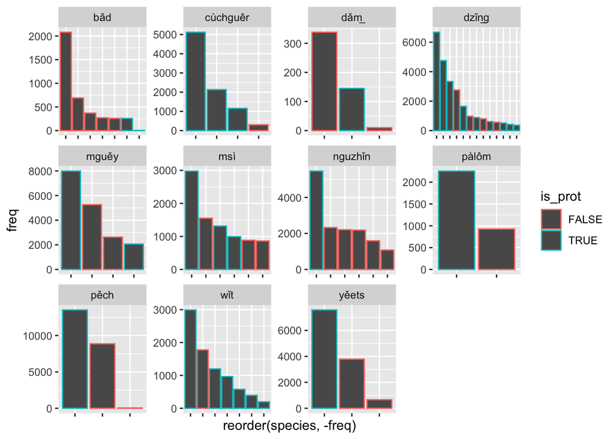

```r
protstatus <- df_mf %>%
  select(folk_generic, is_prot) %>%
  distinct() %>%
  group_by(folk_generic) %>%
  summarize(cnt = n()) %>%
  ungroup() %>%
  filter(cnt>1)

protcats <- inner_join(df_mf, protstatus)

protplot <- protcats %>%
  filter(is_named) %>%
  ggplot(aes(x = reorder(species, -freq), y = freq, color = is_prot)) +
  geom_col() +
  facet_wrap(~folk_generic, scale="free")  +
  theme(axis.text.x=element_blank())

protplot
```

## Morphospace

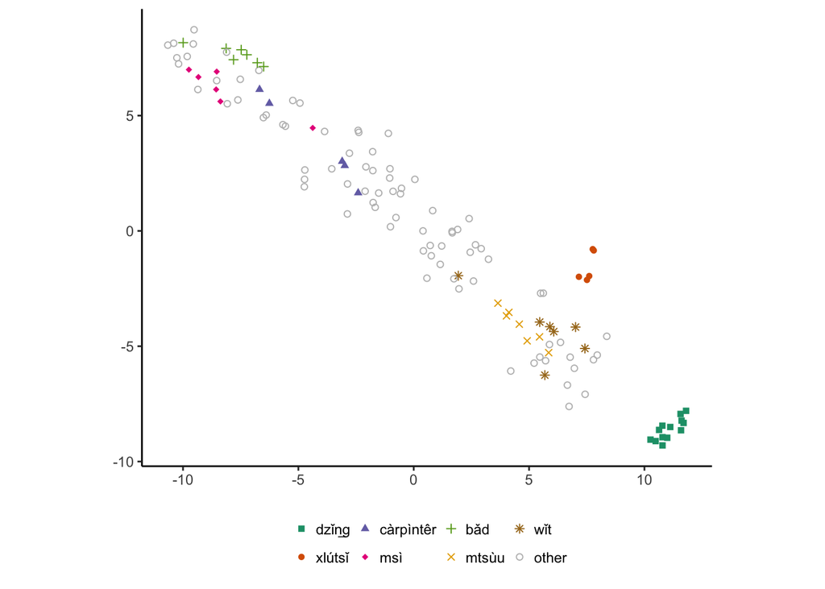

```r
mycolors <- c(brewer.pal(n = 7, name = 'Dark2'), "#BDBDBD")

morphospace_plot <- df_mf %>%
  filter(!is.na(e1) & is_named) %>%
  ggplot(aes(x = e1, y = e2, shape=name, color = name)) +
  #scale_shape_manual(values=1:nlevels(df_mf$plotgen)) +
  scale_shape_manual(values=c(15,16,17,18,3,4,8, 1)) +
  scale_color_manual(values=mycolors) +
  geom_point() +
  coord_fixed() +
  theme_classic() +
  theme(axis.title.x = element_blank(), axis.title.y = element_blank(), legend.title = element_blank()) +
 #theme(plot.margin=grid::unit(c(0,0,0,0), "mm")) +
 theme(legend.position = "bottom", legend.spacing.x = unit(0.1, 'mm'))

morphospace_plot
```

```r
ggsave( here("paper", "figures", "morphospace.png"), width=3.375, units="in")
```

## Named vs Unnamed categories

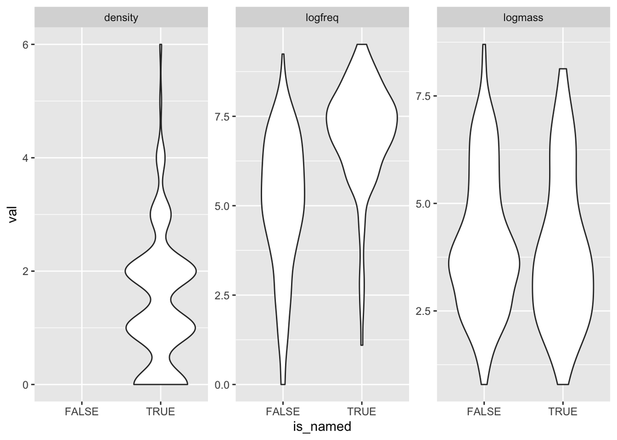

```r
namedvsunnamed_plot <- df_mf_long %>%
  ggplot(aes(x = is_named, y = val)) +
  geom_violin() +
  facet_wrap(~variable, scale="free")
namedvsunnamed_plot
```

```r
naming_full <- glm( formula = is_named ~ logfreq + logmass,  family = binomial, data = df_mf)
naming_freq<- glm( formula = is_named ~ logfreq,  family = binomial, data = df_mf)
naming_mass<- glm( formula = is_named ~ logmass, family = binomial, data = df_mf)
anova(naming_freq, naming_full, naming_mass, test="Chisq")
```

```
## Analysis of Deviance Table
##
## Model 1: is_named ~ logfreq
## Model 2: is_named ~ logfreq + logmass
## Model 3: is_named ~ logmass
##   Resid. Df Resid. Dev Df Deviance Pr(>Chi)
## 1       618     514.51
## 2       617     514.50  1    0.006   0.9401
## 3       618     638.03 -1 -123.524   <2e-16 ***
## ---
## Signif. codes:  0 '***' 0.001 '**' 0.01 '*' 0.05 '.' 0.1 ' ' 1
```

```r
naming_drop <- drop1(naming_full, test="Chisq")
summary(naming_full)
```

```
##
## Call:
## glm(formula = is_named ~ logfreq + logmass, family = binomial,
##     data = df_mf)
##
## Deviance Residuals:
##     Min       1Q   Median       3Q      Max
## -1.6336  -0.6858  -0.4070  -0.1195   3.2080
##
## Coefficients:
##              Estimate Std. Error z value Pr(>|z|)
## (Intercept) -6.008671   0.655124  -9.172   <2e-16 ***
## logfreq      0.759088   0.085087   8.921   <2e-16 ***
## logmass      0.005197   0.069174   0.075     0.94
## ---
## Signif. codes:  0 '***' 0.001 '**' 0.01 '*' 0.05 '.' 0.1 ' ' 1
##
## (Dispersion parameter for binomial family taken to be 1)
##
##     Null deviance: 639.42  on 619  degrees of freedom
## Residual deviance: 514.50  on 617  degrees of freedom
## AIC: 520.5
##
## Number of Fisher Scoring iterations: 5
```

```r
naming_drop
```

```
## Single term deletions
##
## Model:
## is_named ~ logfreq + logmass
##         Df Deviance    AIC     LRT Pr(>Chi)
## <none>       514.50 520.50
## logfreq  1   638.03 642.03 123.524   <2e-16 ***
## logmass  1   514.51 518.51   0.006   0.9401
## ---
## Signif. codes:  0 '***' 0.001 '**' 0.01 '*' 0.05 '.' 0.1 ' ' 1
```

## Lumping analysis

Now we analyze how many other species each named species is lumped with.

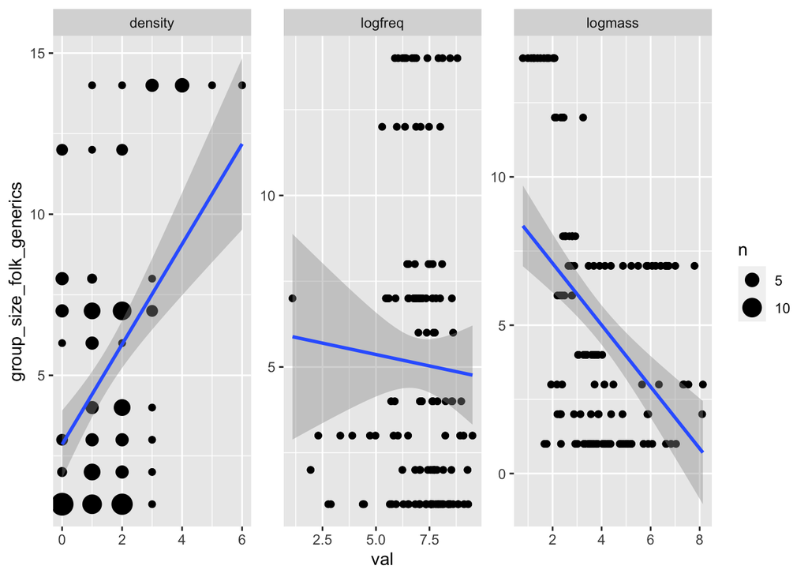

```r
df_named <- df_mf %>%
  filter(is_named) %>%
  mutate(norm_group_size_generic = group_size_folk_generics/group_size_clements)

lumping_plot <- df_mf_long %>%
  filter(is_named) %>%
  ggplot(aes(x = val, y = group_size_folk_generics)) +
  geom_point() +
  geom_count() +
  scale_size_area()+
  geom_smooth(method=lm) +
  facet_wrap(~variable, scales="free")
lumping_plot
```

```r
lmlumping_full <- lm( formula = group_size_folk_generics ~ logfreq + logmass,  data = df_named)
lmlumping_freq <- lm( formula = group_size_folk_generics ~ logfreq,  data = df_named)
lmlumping_mass <- lm( formula = group_size_folk_generics ~ logmass,  data = df_named)

anova(lmlumping_freq, lmlumping_full, lmlumping_mass, test="Chisq")
```

```
## Analysis of Variance Table
##
## Model 1: group_size_folk_generics ~ logfreq
## Model 2: group_size_folk_generics ~ logfreq + logmass
## Model 3: group_size_folk_generics ~ logmass
##   Res.Df    RSS Df Sum of Sq  Pr(>Chi)
## 1    129 2328.6
## 2    128 1823.8  1    504.82 2.643e-09 ***
## 3    129 1902.7 -1    -78.89   0.01862 *
## ---
## Signif. codes:  0 '***' 0.001 '**' 0.01 '*' 0.05 '.' 0.1 ' ' 1
```

```r
#lumping_drop <- drop1(lmlumping, test="Chisq")
#lumping_drop
summary(lmlumping_full)
```

```
##
## Call:
## lm(formula = group_size_folk_generics ~ logfreq + logmass, data = df_named)
##
## Residuals:
##     Min      1Q  Median      3Q     Max
## -6.2514 -3.0661 -0.6829  3.3898  7.0537
##
## Coefficients:
##             Estimate Std. Error t value Pr(>|t|)
## (Intercept)  13.5321     2.0233   6.688 6.33e-10 ***
## logfreq      -0.5462     0.2321  -2.353   0.0201 *
## logmass      -1.1805     0.1983  -5.952 2.38e-08 ***
## ---
## Signif. codes:  0 '***' 0.001 '**' 0.01 '*' 0.05 '.' 0.1 ' ' 1
##
## Residual standard error: 3.775 on 128 degrees of freedom
## Multiple R-squared:  0.2185, Adjusted R-squared:  0.2063
## F-statistic:  17.9 on 2 and 128 DF,  p-value: 1.403e-07
```

## Compound vs monomial

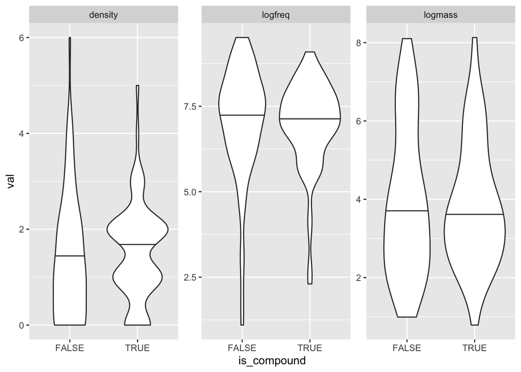

```r
compound_plot <- df_mf_long %>%
  filter(is_named) %>%
  ggplot(aes(x = is_compound, y = val)) +
  geom_violin(draw_quantiles=c(0.5)) +
  facet_wrap(~variable, scale="free")
compound_plot
```

```r
logitmodcompound <- glm(
  formula = is_compound ~ logfreq + logmass,
  family = binomial,
  data = df_named)

compound_drop <- drop1(logitmodcompound, test="Chisq")
compound_drop
```

```
## Single term deletions
##
## Model:
## is_compound ~ logfreq + logmass
##         Df Deviance    AIC      LRT Pr(>Chi)
## <none>       181.42 187.42
## logfreq  1   181.52 185.52 0.098789   0.7533
## logmass  1   181.55 185.55 0.133450   0.7149
```

```r
summary(logitmodcompound)
```

```
##
## Call:
## glm(formula = is_compound ~ logfreq + logmass, family = binomial,
##     data = df_named)
##
## Deviance Residuals:
##    Min      1Q  Median      3Q     Max
## -1.248  -1.184   1.105   1.168   1.266
##
## Coefficients:
##             Estimate Std. Error z value Pr(>|z|)
## (Intercept)  0.43592    1.07427   0.406    0.685
## logfreq     -0.03870    0.12321  -0.314    0.753
## logmass     -0.03842    0.10525  -0.365    0.715
##
## (Dispersion parameter for binomial family taken to be 1)
##
##     Null deviance: 181.60  on 130  degrees of freedom
## Residual deviance: 181.42  on 128  degrees of freedom
## AIC: 187.42
##
## Number of Fisher Scoring iterations: 3
```

## Name length

Suggest not including a figure for this, but just reporting in the text. Effect of frequency goes in opposite way compared to the compound vs monomial analysis (more common things have longer names)

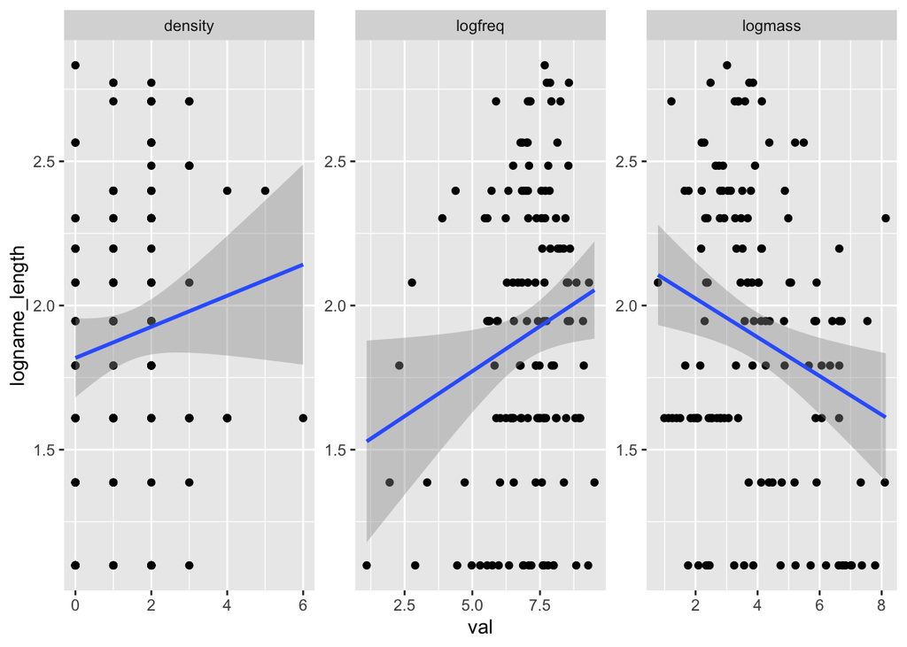

```r
namelength_plot <- df_mf_long %>%
  filter(is_named) %>%
  ggplot(aes(x = val, y = logname_length)) +
  geom_point() +
  geom_smooth(method=lm) +
  facet_wrap(~variable, scale="free")
namelength_plot
```

```r
namelength_full <- lm( formula = logname_length ~ logfreq + logmass,  data = df_named)
namelength_freq <- lm( formula = logname_length ~ logfreq,  data = df_named)
namelength_mass <- lm( formula = logname_length ~ logmass,  data = df_named)

#namelength_drop <- drop1(namelength_full, test="Chisq")
#namelength_drop

anova(namelength_freq, namelength_full, namelength_mass, test="Chisq")
```

```
## Analysis of Variance Table
##
## Model 1: logname_length ~ logfreq
## Model 2: logname_length ~ logfreq + logmass
## Model 3: logname_length ~ logmass
##   Res.Df    RSS Df Sum of Sq Pr(>Chi)
## 1    129 31.757
## 2    128 30.607  1   1.15008   0.0283 *
## 3    129 31.088 -1  -0.48168   0.1558
## ---
## Signif. codes:  0 '***' 0.001 '**' 0.01 '*' 0.05 '.' 0.1 ' ' 1
```

```r
summary(namelength_full)
```

```
##
## Call:
## lm(formula = logname_length ~ logfreq + logmass, data = df_named)
##
## Residuals:
##      Min       1Q   Median       3Q      Max
## -0.99770 -0.40305  0.05988  0.38056  0.85742
##
## Coefficients:
##             Estimate Std. Error t value Pr(>|t|)
## (Intercept)  1.81811    0.26211   6.937 1.78e-10 ***
## logfreq      0.04268    0.03007   1.419   0.1582
## logmass     -0.05635    0.02569  -2.193   0.0301 *
## ---
## Signif. codes:  0 '***' 0.001 '**' 0.01 '*' 0.05 '.' 0.1 ' ' 1
##
## Residual standard error: 0.489 on 128 degrees of freedom
## Multiple R-squared:  0.06936,    Adjusted R-squared:  0.05482
## F-statistic:  4.77 on 2 and 128 DF,  p-value: 0.01005
```

## Overall conclusions

#### Frequency

- decent evidence that frequency predicts whether or not a species is named
- only weak evidence that frequency predicts lumping
- no effect of frequency on compound vs monomial or name length

#### Mass

- replicate Hunn’s finding that size predicts lumping (and find that it’s a stronger predictor than frequency)
- only weak evidence that mass predicts anything else

#### Themes for discussion:

- reasons why we don’t see a stronger effect of frequency (discuss wrt theories that do predict frequency effects including functional/utilitarian view, Zipfian view, perhaps others)
- distribution of species in morphospace is an important confound in lumping, compound vs monomial and namelength analyses. Possible that similarity is the big thing: e.g if a species is very similar to many other species than we’d expect to have a high lumping score independent of mass and frequency, and might also expect to have a compound name that reflects the relationship of the species to other similar things.
- Future direction: include similarity as predictor. Use the data in that recent paper (Macroevolutionary convergence connects morphological form to ecological function in birds) to add a “neighborhood density” variable that captures how many other local species a given species is similar to.

## Caveats

This notebook is a quick attempt to generate results we can include in a minimal submittable draft. At some stage we should

- confirm that setting `test=Chisq` in the call to `drop1()` is what we actually want.
- look at residuals and try other kinds of model-checking
- consider mixed effects analyses with random effects for Clemens group